# Panther GLMM

Wenjing Xu

3/4/2020

## Data exploration

```r
# Ave_Dry and Ave_Wet correlated, select wet.
# Home range and DenID should only pick one.
data <- data %>% dplyr::select(Used, CatID, DenID, Fire_Cat, Age, Ave_Wet, Prec_Tree, dist2build, Combined) %>% dplyr:: rename(Veg_Class = Combined)
# specify factors
data$CatID <- as.factor(data$CatID)
data$DenID <- as.factor(data$DenID)
data$Fire_Cat <- as.factor(data$Fire_Cat)
data$Veg_Class <- factor(data$Veg_Class, levels = c("Upland Forest", "Other", "Human Modified", "Marsh-Shrub-Swamp", "Prairie-Grassland", "Wetland Forest"))

data.1 <- data %>% filter (Used == "1") %>% group_by(Fire_Cat) %>% summarise(used.count = n())
data.1
```

```
## # A tibble: 5 x 2
##   Fire_Cat used.count
##   <fct>         <int>
## 1 A                10
## 2 B                 9
## 3 C                16
## 4 D                 8
## 5 U                40
```

We have a lot of points in U. Unbalanced dataset.

```r
cor(data[,c(5:8)]) #does not seem to have strong linear relations
```

```
##                    Age     Ave_Wet    Prec_Tree   dist2build
## Age         1.00000000 -0.06120271 -0.044031175  0.172344234
## Ave_Wet    -0.06120271  1.00000000 -0.205430642 -0.026244981
## Prec_Tree  -0.04403117 -0.20543064  1.000000000  0.004380176
## dist2build  0.17234423 -0.02624498  0.004380176  1.000000000
```

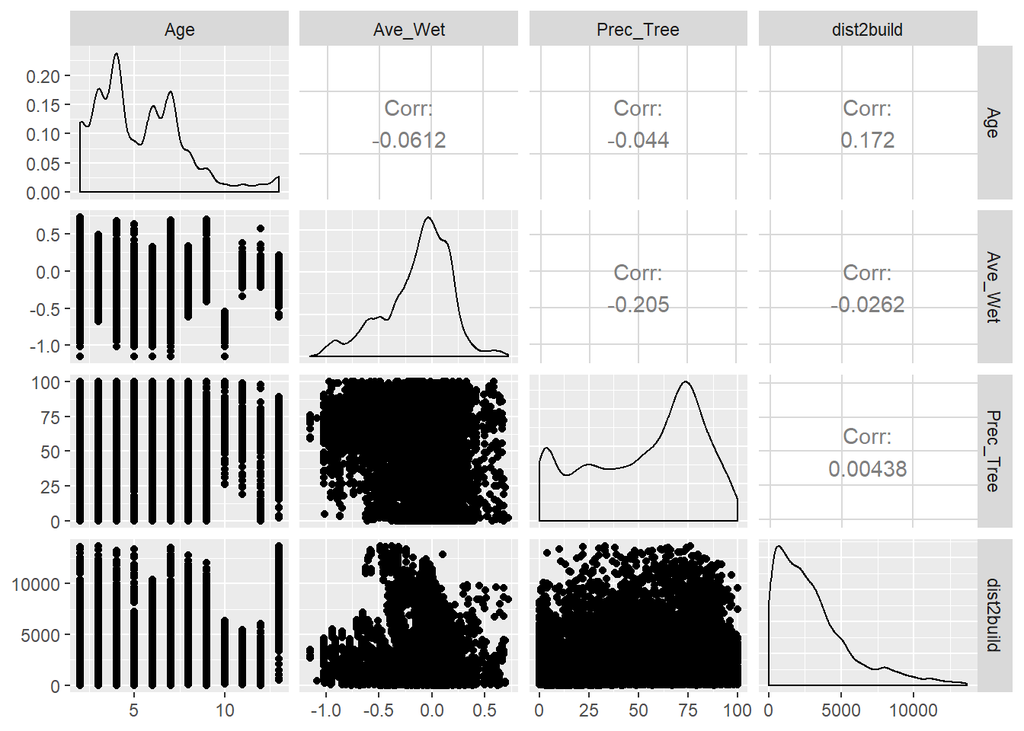

```r
ggpairs(data[, c("Age", "Ave_Wet", "Prec_Tree", "dist2build")])
```

This plot further confirmed that there are no obvious linear relations. Yet, it seems like dist2build has very skewed distribution (lots of 0s). So later when scaling, we will conduct a log(x+1) transformation for dist2biuld before standardizing.

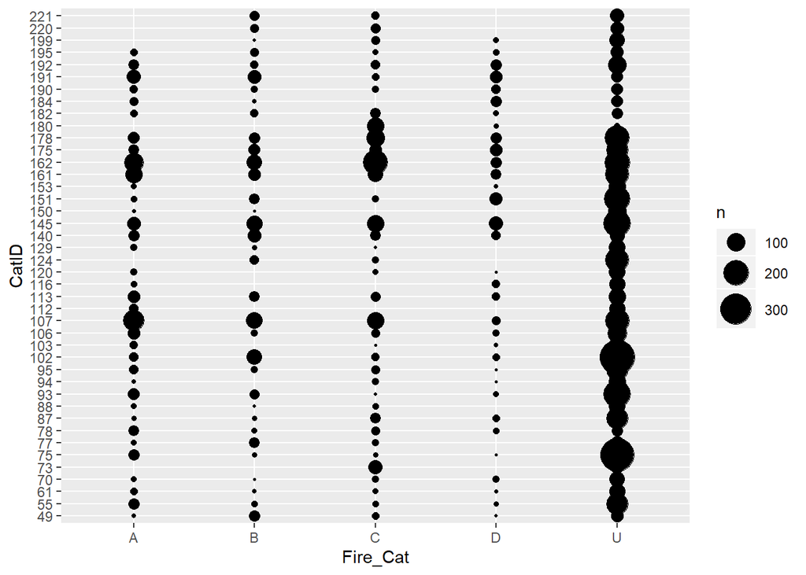

```r
# all points
par(mfrow = c(1, 2))
ggplot(data, aes(x = Fire_Cat, y = CatID)) +
  stat_sum(aes(size = ..n.., group = Fire_Cat)) +
  scale_size_area(max_size=10)
```

```r
# only den
# ggplot(data %>% filter (Used == "1"), aes(x = Fire_Cat, y = CatID)) +
#   stat_sum(aes(size = ..n.., group = Fire_Cat)) +
#   scale_size_area(max_size=10)
```

Lots of U.

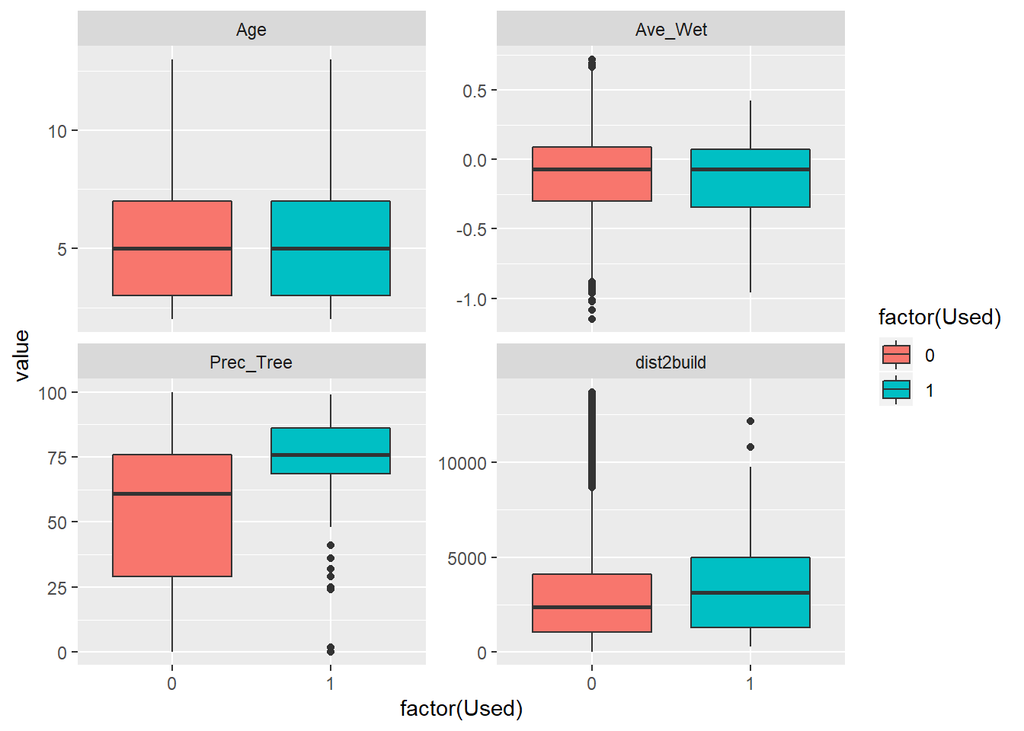

```r
data.2 <- melt(data[, c("Used", "Age", "Ave_Wet", "Prec_Tree", "dist2build")], id.vars="Used")
ggplot(data.2, aes(factor(Used), y = value, fill=factor(Used))) +
    geom_boxplot() +
    facet_wrap(~variable, scales="free_y")
```

Super clear that they pick high tree precentage area. slightly far away from building, almost no difference in age and ave wet. We will see in the real model.

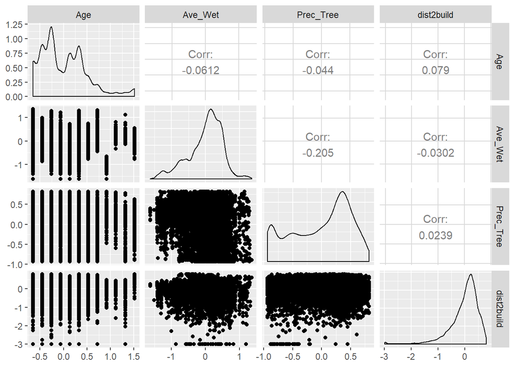

```r
# scaling numeric variables by deviding two standard deviations for binary predictors
# http://www.stat.columbia.edu/~gelman/research/published/standardizing7.pdf
data.scaled <- data
data.scaled$dist2build <- log(data.scaled$dist2build + 1)
data.scaled[,5:8] <- sapply(data.scaled[,5:8], rescale, binary.inputs = "full")
#data.scaled$Ave_Wet <- sqrt(data.scaled$Ave_Wet)
#data.scaled$Prec_Tree <- sqrt(data.scaled$Prec_Tree)  # issue: take sqrt creates lots of NA
ggpairs(data.scaled[, c("Age", "Ave_Wet", "Prec_Tree", "dist2build")])
```

The table shows we have a unbalanced dataset in terms of Fire_Cat. In principle, lme4 can deal with unbalanced data sets but the low number of data points in some cells of the design means that it is hard to estimate some of the effects.

Dist2building looks pretty skewed.

## fitting and diagnostic glmer

```r
# full model
m.0 <- glmer(Used ~ Fire_Cat + Prec_Tree + Veg_Class + Age + Ave_Wet + dist2build + (1|CatID), data = data.scaled, family = binomial, nAGQ = 10)
```

```
## boundary (singular) fit: see ?isSingular
```

```r
#print(m.0, correlation = FALSE)
summary(m.0)
```

```
## Generalized linear mixed model fit by maximum likelihood (Adaptive
##   Gauss-Hermite Quadrature, nAGQ = 10) [glmerMod]
##  Family: binomial  ( logit )
## Formula:
## Used ~ Fire_Cat + Prec_Tree + Veg_Class + Age + Ave_Wet + dist2build +
##     (1 | CatID)
##    Data: data.scaled
##
##      AIC      BIC   logLik deviance df.resid
##    896.7   1002.2   -433.4    866.7     8352
##
## Scaled residuals:
##     Min      1Q  Median      3Q     Max
## -0.5360 -0.1178 -0.0867 -0.0522 26.2872
##
## Random effects:
##  Groups Name        Variance Std.Dev.
##  CatID  (Intercept) 0        0
## Number of obs: 8367, groups:  CatID, 42
##
## Fixed effects:
##                            Estimate Std. Error z value Pr(>|z|)
## (Intercept)                -4.66237    0.40178 -11.604  < 2e-16 ***
## Fire_CatB                   0.10802    0.46451   0.233  0.81611
## Fire_CatC                   0.47176    0.40868   1.154  0.24835
## Fire_CatD                   0.42688    0.48189   0.886  0.37570
## Fire_CatU                  -0.10473    0.36503  -0.287  0.77418
## Prec_Tree                   1.92719    0.36252   5.316 1.06e-07 ***
## Veg_ClassOther              2.59362    0.82602   3.140  0.00169 **
## Veg_ClassHuman Modified     0.64675    1.06495   0.607  0.54364
## Veg_ClassMarsh-Shrub-Swamp -0.40261    0.40185  -1.002  0.31640
## Veg_ClassPrairie-Grassland -0.89886    0.51868  -1.733  0.08310 .
## Veg_ClassWetland Forest    -0.48563    0.29707  -1.635  0.10211
## Age                         0.02314    0.22190   0.104  0.91694
## Ave_Wet                     0.19027    0.23162   0.821  0.41137
## dist2build                  0.44614    0.27189   1.641  0.10082
## ---
## Signif. codes:  0 '***' 0.001 '**' 0.01 '*' 0.05 '.' 0.1 ' ' 1
```

```
##
## Correlation matrix not shown by default, as p = 14 > 12.
## Use print(x, correlation=TRUE)  or
##     vcov(x)        if you need it
```

```
## convergence code: 0
## boundary (singular) fit: see ?isSingular
```

```r
# the next model treat catID as fixed variable. But should not do that becasue too many levels.
# m.1 <- glm(Used ~ Fire_Cat + Prec_Tree + Veg_Class + Prec_Tree + Age + Ave_Wet + dist2build + CatID, data = data.scaled, family = binomial)

m.2 <- glm(Used ~ Fire_Cat + Prec_Tree + Veg_Class + Age + Ave_Wet + dist2build, data = data.scaled, family = binomial)
#print(m.2, correlation = FALSE)
summary(m.2)
```

```
##
## Call:
## glm(formula = Used ~ Fire_Cat + Prec_Tree + Veg_Class + Age +
##     Ave_Wet + dist2build, family = binomial, data = data.scaled)
##
## Deviance Residuals:
##     Min       1Q   Median       3Q      Max
## -0.7107  -0.1661  -0.1224  -0.0738   3.6165
##
## Coefficients:
##                            Estimate Std. Error z value Pr(>|z|)
## (Intercept)                -4.66237    0.40178 -11.604  < 2e-16 ***
## Fire_CatB                   0.10802    0.46451   0.233  0.81611
## Fire_CatC                   0.47176    0.40867   1.154  0.24835
## Fire_CatD                   0.42688    0.48188   0.886  0.37570
## Fire_CatU                  -0.10473    0.36502  -0.287  0.77417
## Prec_Tree                   1.92719    0.36251   5.316 1.06e-07 ***
## Veg_ClassOther              2.59362    0.82601   3.140  0.00169 **
## Veg_ClassHuman Modified     0.64675    1.06493   0.607  0.54364
## Veg_ClassMarsh-Shrub-Swamp -0.40261    0.40184  -1.002  0.31639
## Veg_ClassPrairie-Grassland -0.89886    0.51868  -1.733  0.08310 .
## Veg_ClassWetland Forest    -0.48563    0.29707  -1.635  0.10211
## Age                         0.02314    0.22190   0.104  0.91694
## Ave_Wet                     0.19027    0.23162   0.821  0.41136
## dist2build                  0.44614    0.27189   1.641  0.10081
## ---
## Signif. codes:  0 '***' 0.001 '**' 0.01 '*' 0.05 '.' 0.1 ' ' 1
##
## (Dispersion parameter for binomial family taken to be 1)
##
##     Null deviance: 930.97  on 8366  degrees of freedom
## Residual deviance: 866.73  on 8353  degrees of freedom
## AIC: 894.73
##
## Number of Fisher Scoring iterations: 8
```

```r
# with one less variable
m.3 <- glm(Used ~ Fire_Cat + Prec_Tree + Veg_Class + Ave_Wet + dist2build, data = data.scaled, family = binomial)
m.4 <- glm(Used ~ Fire_Cat + Prec_Tree + Veg_Class + Age + dist2build, data = data.scaled, family = binomial)
m.5 <- glm(Used ~ Fire_Cat + Prec_Tree + Veg_Class + Age + Ave_Wet, data = data.scaled, family = binomial)

# with two less variables
m.6 <- glm(Used ~ Fire_Cat + Prec_Tree + Veg_Class + dist2build, data = data.scaled, family = binomial)
m.7 <- glm(Used ~ Fire_Cat + Prec_Tree + Veg_Class + Age, data = data.scaled, family = binomial)
m.8 <- glm(Used ~ Fire_Cat + Prec_Tree + Veg_Class + Ave_Wet, data = data.scaled, family = binomial)

m.9 <- glm(Used ~ Fire_Cat + Prec_Tree + Veg_Class , data = data.scaled, family = binomial)
summary(m.9)
```

```
##
## Call:
## glm(formula = Used ~ Fire_Cat + Prec_Tree + Veg_Class, family = binomial,
##     data = data.scaled)
##
## Deviance Residuals:
##     Min       1Q   Median       3Q      Max
## -0.7387  -0.1670  -0.1243  -0.0744   3.6866
##
## Coefficients:
##                            Estimate Std. Error z value Pr(>|z|)
## (Intercept)                 -4.6321     0.3981 -11.636  < 2e-16 ***
## Fire_CatB                    0.1121     0.4641   0.241  0.80921
## Fire_CatC                    0.4551     0.4075   1.117  0.26411
## Fire_CatD                    0.4829     0.4801   1.006  0.31450
## Fire_CatU                   -0.1088     0.3597  -0.302  0.76227
## Prec_Tree                    1.9295     0.3595   5.367 8.02e-08 ***
## Veg_ClassOther               2.6087     0.8222   3.173  0.00151 **
## Veg_ClassHuman Modified      0.3506     1.0505   0.334  0.73861
## Veg_ClassMarsh-Shrub-Swamp  -0.3598     0.4014  -0.896  0.37007
## Veg_ClassPrairie-Grassland  -0.9388     0.5182  -1.812  0.07001 .
## Veg_ClassWetland Forest     -0.5158     0.2966  -1.739  0.08201 .
## ---
## Signif. codes:  0 '***' 0.001 '**' 0.01 '*' 0.05 '.' 0.1 ' ' 1
##
## (Dispersion parameter for binomial family taken to be 1)
##
##     Null deviance: 930.97  on 8366  degrees of freedom
## Residual deviance: 870.38  on 8356  degrees of freedom
## AIC: 892.38
##
## Number of Fisher Scoring iterations: 8
```

m.0 and m.2 are besically identical because the random factor could not be taken into consideration in m.0

The below is a test to see whether the model is significantly better than null model - and they all seems better than null model.

```r
foo <- function(x) with(x, pchisq(null.deviance - deviance, df.null - df.residual, lower.tail = FALSE))
foo(m.2)
```

```
## [1] 9.055311e-09
```

Compare models

```r
#first, analysis of deviance
#The deviance is somewhat analogous to the variance analyzed in an ANOVA, at least to the extent that the goal of modeling is to explain as much as possible of deviance.
anova(m.2, m.3,m.4, m.5, test = "Chi")
```

```
## Analysis of Deviance Table
##
## Model 1: Used ~ Fire_Cat + Prec_Tree + Veg_Class + Age + Ave_Wet + dist2build
## Model 2: Used ~ Fire_Cat + Prec_Tree + Veg_Class + Ave_Wet + dist2build
## Model 3: Used ~ Fire_Cat + Prec_Tree + Veg_Class + Age + dist2build
## Model 4: Used ~ Fire_Cat + Prec_Tree + Veg_Class + Age + Ave_Wet
##   Resid. Df Resid. Dev Df Deviance Pr(>Chi)
## 1      8353     866.73
## 2      8354     866.74 -1 -0.01084   0.9171
## 3      8354     867.41  0 -0.67503
## 4      8354     869.65  0 -2.24229
```

```r
AIC(m.2, m.3,m.4, m.5, m.6, m.7, m.8, m.9)
```

```
##     df      AIC
## m.2 14 894.7263
## m.3 13 892.7372
## m.4 13 893.4122
## m.5 13 895.6545
## m.6 12 891.4141
## m.7 12 894.3404
## m.8 12 893.7116
## m.9 11 892.3761
```

All super similar AIC…

```r
# this confident interval is calculated based on maximum likihood
# note that the numbers here are log-transformed
co.table <- cbind(OR = coef(m.2), confint(m.2))
```

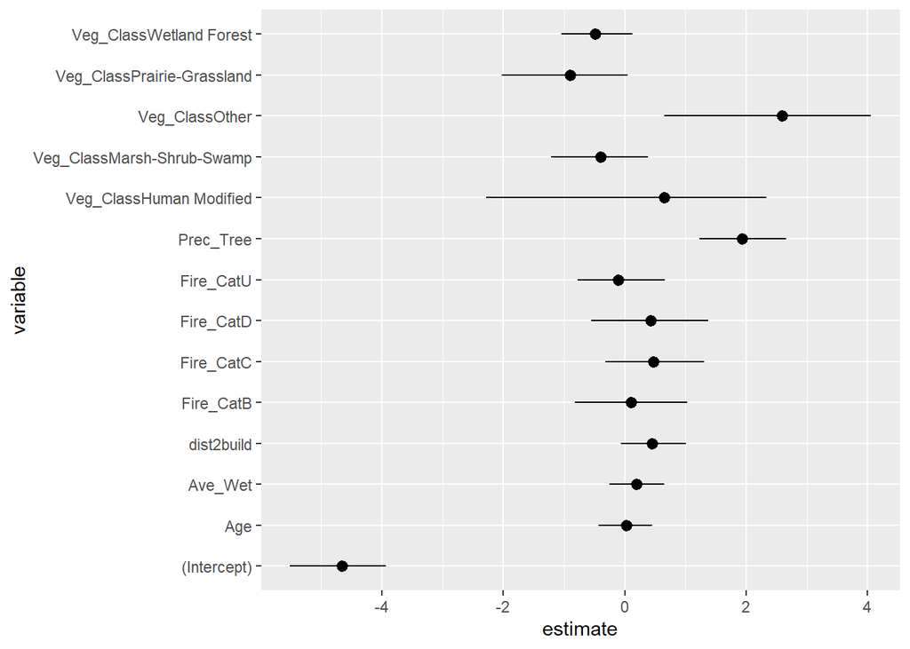

```r
co.df <- data.frame(variable = row.names(co.table), estimate = co.table[1:nrow(co.table), 1], LL = co.table[1:nrow(co.table), 2], UL =  co.table[1:nrow(co.table), 3])
co.df$variable <- as.character(co.df$variable)

ggplot(co.df, aes(y=estimate, x=variable, ymin=LL, ymax=UL)) + geom_pointrange() + coord_flip()
```

We can test for an overall effect of rank using the wald.test function of the aod library. The order in which the coefficients are given in the table of coefficients is the same as the order of the terms in the model. This is important because the wald.test function refers to the coefficients by their order in the model. We use the wald.test function.

```r
wald.test(b = coef(m.2), Sigma = vcov(m.2), Terms = 1:5)
```

```
## Wald test:
## ----------
##
## Chi-squared test:
## X2 = 256.6, df = 5, P(> X2) = 0.0
```

We can also test additional hypotheses about the differences in the coefficients for the different levels of rank. To contrast these two terms, we multiply one of them by 1, and the other by -1. The other terms in the model are not involved in the test, so they are multiplied by 0. The second line of code below uses L=l to tell R that we wish to base the test on the vector l (rather than using the Terms option as we did above).

```r
l <- cbind(1, -1, 0, 0, 0 ,0 ,0 ,0 ,0 ,0 ,0 ,0 ,0 ,0)
wald.test(b = coef(m.2), Sigma = vcov(m.2), L = l)
```

```
## Wald test:
## ----------
##
## Chi-squared test:
## X2 = 39.8, df = 1, P(> X2) = 2.8e-10
```

```r
l <- cbind(0, 0, 0, 1, -1 ,0 ,0 ,0 ,0 ,0 ,0 ,0 ,0,0 )
wald.test(b = coef(m.2), Sigma = vcov(m.2), L = l)
```

[output not shown]

It looks like only A is significantly different from other fire cat.

Now exponentiate the coefficients and interpret them as odds-ratios.

```r
### odds ratios and 95% CI
exp(cbind(OR = coef(m.2), confint(m.2)))
```

```
##                                      OR       2.5 %      97.5 %
## (Intercept)                 0.009444076 0.004044617  0.01970537
## Fire_CatB                   1.114073855 0.438494043  2.79054594
## Fire_CatC                   1.602809918 0.729385640  3.69397380
## Fire_CatD                   1.532468466 0.577094404  3.94196904
## Fire_CatU                   0.900565966 0.457460410  1.94234031
## Prec_Tree                   6.870169819 3.439924404 14.29952190
## Veg_ClassOther             13.378058063 1.923509591 57.46560392
## Veg_ClassHuman Modified     1.909334363 0.102343521 10.37131496
## Veg_ClassMarsh-Shrub-Swamp  0.668574358 0.298974693  1.46433445
## Veg_ClassPrairie-Grassland  0.407034339 0.131809819  1.05375953
## Veg_ClassWetland Forest     0.615312109 0.351079482  1.13395740
## Age                         1.023411377 0.653077665  1.56183989
## Ave_Wet                     1.209578061 0.774573149  1.92289370
## dist2build                  1.562276788 0.940073371  2.73101774
```

Create a table to plot predict probabilities varying percent tree

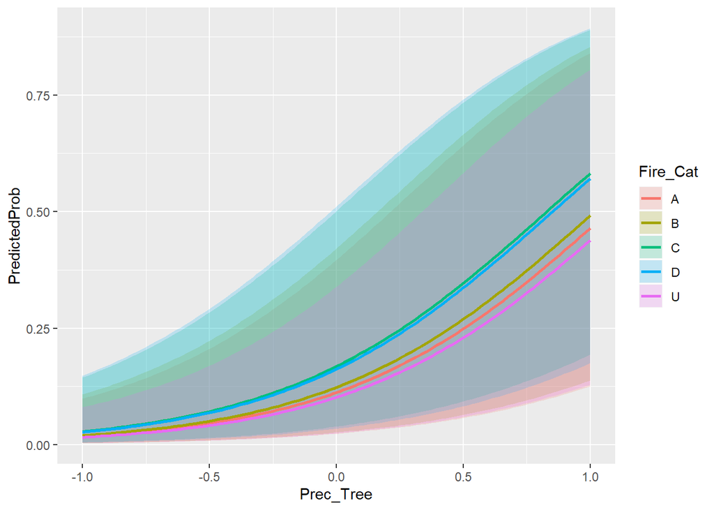

```r
newdata <- with(data.scaled[4:9], data.frame(Fire_Cat = factor(rep(c("A", "B", "C", "D", "U"), each = 100)),
                                                          Age = mean(data.scaled$Age),
                                                          Ave_Wet = mean(data.scaled$Ave_Wet),
                                                          Prec_Tree = rep(seq(from = -1, to = 1, length.out = 100), 5),
                                                          dist2build = mean(data.scaled$dist2build),
                                                          Veg_Class = "Other"))

newdata <- cbind(newdata, predict(m.2, newdata = newdata, type = "link", se = TRUE))
newdata <- within(newdata, {
  PredictedProb <- plogis(fit)
  LL <- plogis(fit - (1.96 * se.fit))
  UL <- plogis(fit + (1.96 * se.fit))
})

p.1 <- ggplot(newdata, aes(x = Prec_Tree, y = PredictedProb)) + geom_ribbon(aes(ymin = LL,
    ymax = UL, fill = Fire_Cat), alpha = 0.2) + geom_line(aes(colour = Fire_Cat),
    size = 1)
p.1
```

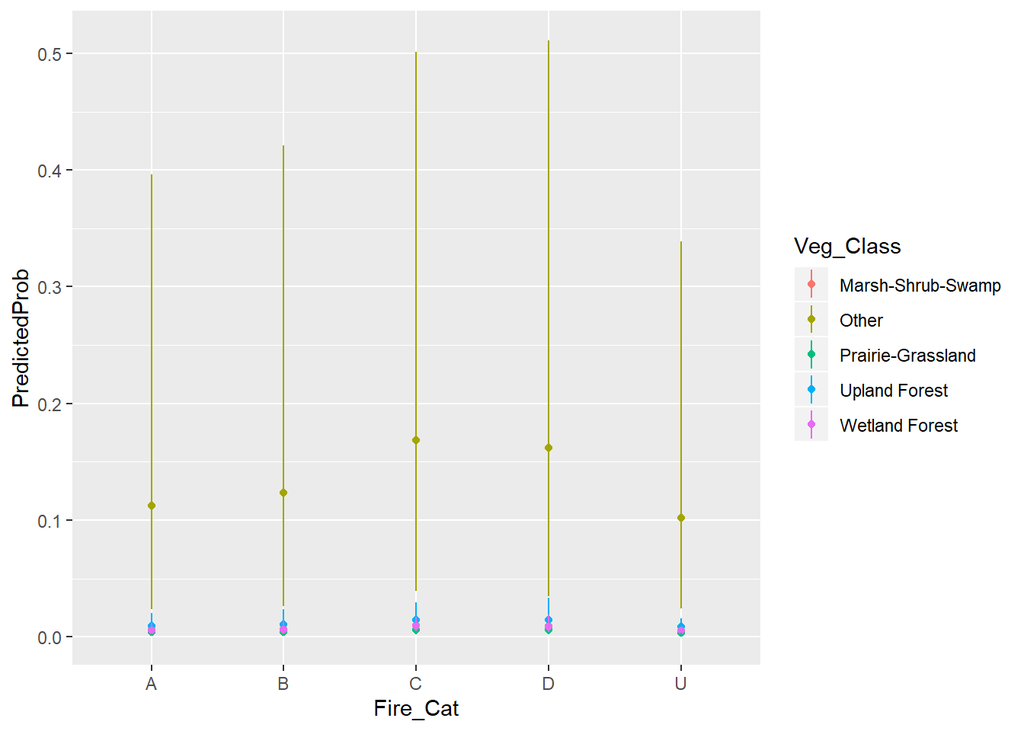

```r
newdata2 <- with(data.scaled[4:9], data.frame(Fire_Cat = factor(rep(c("A", "B", "C", "D", "U"), each = 5)),
                                                          Age = mean(data.scaled$Age),
                                                          Ave_Wet = mean(data.scaled$Ave_Wet),
                                                          Prec_Tree = mean(data.scaled$Prec_Tree),
                                                          dist2build = mean(data.scaled$dist2build),
                                                          Veg_Class = rep(c("Other", "Marsh-Shrub-Swamp", "Prairie-Grassland", "Upland Forest", "Wetland Forest"), 5)))

newdata2 <- cbind(newdata2, predict(m.2, newdata = newdata2, type = "link", se = TRUE))
newdata2 <- within(newdata2, {
  PredictedProb <- plogis(fit)
  LL <- plogis(fit - (1.96 * se.fit))
  UL <- plogis(fit + (1.96 * se.fit))
})

p.2 <- ggplot(newdata2, aes(x = Fire_Cat, y = PredictedProb, colour = Veg_Class)) +
  geom_point() +
  geom_linerange(aes(ymin = LL, ymax = UL))
p.2
```

“Other” is significantly higher than other classes. Need to further tease apart different classes.